# iv

kenjimyzk

2017-08-04

SW12章の表12.1を再現する. まず以下のライブラリを導入する

```r
library(knitr)
library(mosaic)
library(AER)
library(texreg)
library(tidyverse)
library(broom)
```

データ生成は以下のとおりである

```r
data("CigarettesSW", package = "AER")
df <- CigarettesSW %>%
  mutate(tdiff=(taxs - tax)/cpi,
         rprice=price/cpi,
         rincome = income/population/cpi)
df1995 <- filter(df,year=="1995")
head(df1995)
```

```
##   state year   cpi population     packs    income      tax    price
## 1    AL 1995 1.524    4262731 101.08543  83903280 40.50000 158.3713
## 2    AR 1995 1.524    2480121 111.04297  45995496 55.50000 175.5425
## 3    AZ 1995 1.524    4306908  71.95417  88870496 65.33333 198.6075
## 4    CA 1995 1.524   31493524  56.85931 771470144 61.00000 210.5047
## 5    CO 1995 1.524    3738061  82.58292  92946544 44.00000 167.3500
## 6    CT 1995 1.524    3265293  79.47219 104315120 74.00000 218.2805
##       taxs     tdiff   rprice  rincome
## 1 41.90467 0.9216975 103.9182 12.91535
## 2 63.85917 5.4850193 115.1854 12.16907
## 3 74.79082 6.2057067 130.3199 13.53964
## 4 74.77133 9.0363074 138.1264 16.07359
## 5 44.00000 0.0000000 109.8097 16.31556
## 6 86.35550 8.1072834 143.2287 20.96236
```

またロバスト分散を何度も計算するため次の関数を作っておく.

```r
## convenience function: HC1 covariances
hc1 <- function(x) vcovHC(x, type = "HC1")
```

作図

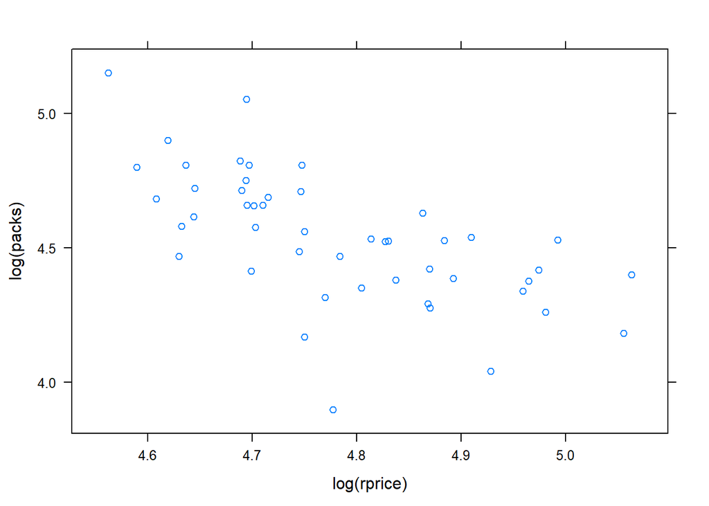

```r
## plot
xyplot(log(packs)~log(rprice),data=df1995)
```

単回帰

```r
fm_ols <- lm(log(packs) ~ log(rprice),data = df1995)
coeftest(fm_ols, vcov = hc1)
```

```
##
## t test of coefficients:
##
##             Estimate Std. Error t value  Pr(>|t|)
## (Intercept) 10.33892    0.93482 11.0598 1.502e-14 ***
## log(rprice) -1.21306    0.19459 -6.2339 1.290e-07 ***
## ---
## Signif. codes:  0 '***' 0.001 '**' 0.01 '*' 0.05 '.' 0.1 ' ' 1
```

作図すると以下になる.

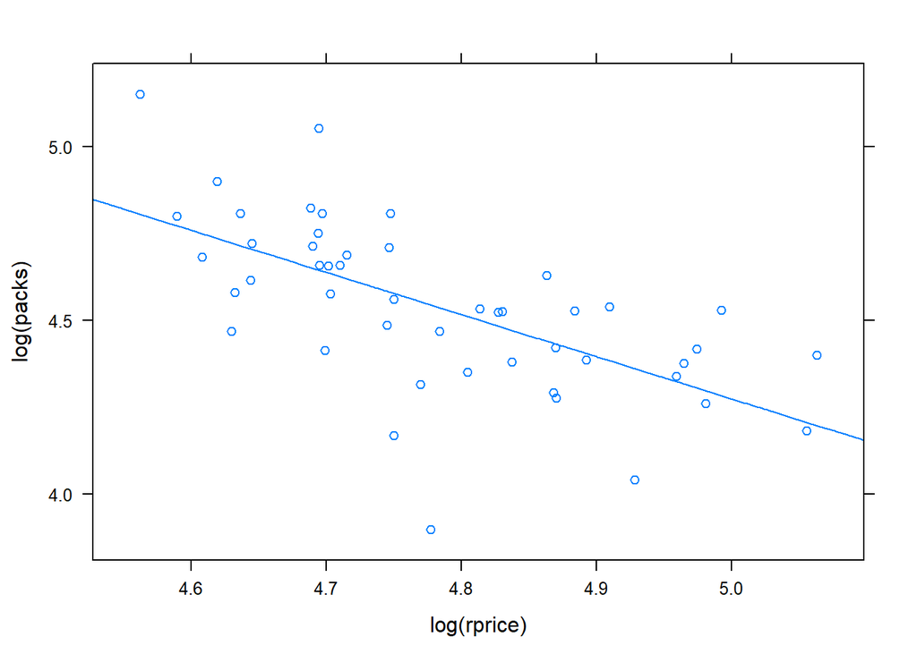

```r
fn_ols <- makeFun(fm_ols)
plotFun(log(fn_ols(exp(rprice)))~log(rprice),add=TRUE)
```

式 (12.11) を再現する. 第一段階の回帰式 (12.9) は以下である.

```r
fm_s1 <- lm(log(rprice) ~ tdiff, data = df1995)
coeftest(fm_s1, vcov = hc1)
```

```
##
## t test of coefficients:
##
##              Estimate Std. Error  t value  Pr(>|t|)
## (Intercept) 4.6165463  0.0289177 159.6444 < 2.2e-16 ***
## tdiff       0.0307289  0.0048354   6.3549 8.489e-08 ***
## ---
## Signif. codes:  0 '***' 0.001 '**' 0.01 '*' 0.05 '.' 0.1 ' ' 1
```

この回帰式の予測値を説明変数にして回帰すると以下になる.

```r
df1995 <- mutate(df1995, frprice=fitted(fm_s1))
fm_s2 <- lm(log(packs) ~ frprice, data = df1995)
coeftest(fm_s2, vcov = hc1)
```

```
##
## t test of coefficients:
##
##             Estimate Std. Error t value  Pr(>|t|)
## (Intercept)   9.7199     1.5971  6.0859 2.153e-07 ***
## frprice      -1.0836     0.3337 -3.2472  0.002178 **
## ---
## Signif. codes:  0 '***' 0.001 '**' 0.01 '*' 0.05 '.' 0.1 ' ' 1
```

回帰式の結果を図示すると以下になる.

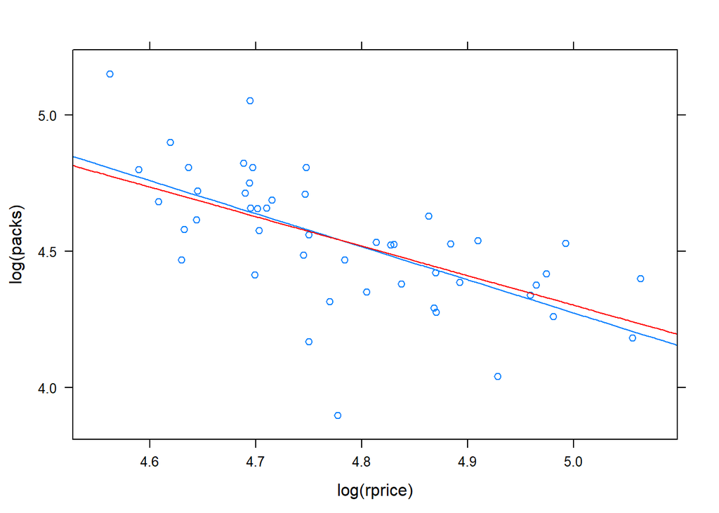

```r
fn_iv <- makeFun(fm_s2)
plotFun(log(fn_iv(rprice))~rprice,add=TRUE, col="red")
```

ただ係数の標準誤差が微妙に一致していない. 一致させるためには次のコマンドを実施する.

```r
fm_ivreg <- ivreg(log(packs) ~ log(rprice) | tdiff, data = df1995)
summary(fm_ivreg, vcov = hc1)
```

```
##
## Call:
## ivreg(formula = log(packs) ~ log(rprice) | tdiff, data = df1995)
##
## Residuals:
##      Min       1Q   Median       3Q      Max
## -0.64619 -0.07732  0.02981  0.11283  0.41904
##
## Coefficients:
##             Estimate Std. Error t value Pr(>|t|)
## (Intercept)   9.7199     1.5283   6.360 8.35e-08 ***
## log(rprice)  -1.0836     0.3189  -3.398  0.00141 **
## ---
## Signif. codes:  0 '***' 0.001 '**' 0.01 '*' 0.05 '.' 0.1 ' ' 1
##
## Residual standard error: 0.1904 on 46 degrees of freedom
## Multiple R-Squared: 0.4011,  Adjusted R-squared: 0.3881
## Wald test: 11.54 on 1 and 46 DF,  p-value: 0.001411
```

```r
fitted(fm_s2)
```

```
##        1        2        3        4        5        6        7        8
## 4.686759 4.534812 4.510815 4.416563 4.717449 4.447497 4.717449 4.485296
##        9       10       11       12       13       14       15       16
## 4.686174 4.518844 4.530552 4.471990 4.556670 4.535158 4.536913 4.576445
##       17       18       19       20       21       22       23       24
## 4.491570 4.523897 4.473530 4.419586 4.402493 4.687114 4.475560 4.717449
##       25       26       27       28       29       30       31       32
## 4.591404 4.479691 4.527911 4.717449 4.466287 4.534184 4.422146 4.531014
##       33       34       35       36       37       38       39       40
## 4.544853 4.540438 4.717449 4.499585 4.396617 4.558454 4.576241 4.447064
##       41       42       43       44       45       46       47       48
## 4.472328 4.529159 4.544052 4.534712 4.375677 4.507929 4.511514 4.717449
```

これは以下のようにして計算される

```r
coef(fm_s2)[1] + coef(fm_s2)[2] * fitted(fm_s1)
```

```
##        1        2        3        4        5        6        7        8
## 4.686759 4.534812 4.510815 4.416563 4.717449 4.447497 4.717449 4.485296
##        9       10       11       12       13       14       15       16
## 4.686174 4.518844 4.530552 4.471990 4.556670 4.535158 4.536913 4.576445
##       17       18       19       20       21       22       23       24
## 4.491570 4.523897 4.473530 4.419586 4.402493 4.687114 4.475560 4.717449
##       25       26       27       28       29       30       31       32
## 4.591404 4.479691 4.527911 4.717449 4.466287 4.534184 4.422146 4.531014
##       33       34       35       36       37       38       39       40
## 4.544853 4.540438 4.717449 4.499585 4.396617 4.558454 4.576241 4.447064
##       41       42       43       44       45       46       47       48
## 4.472328 4.529159 4.544052 4.534712 4.375677 4.507929 4.511514 4.717449
```

正しい予測値の計算は以下である.

```r
coef(fm_s2)[1] + coef(fm_s2)[2] * log(df1995$rprice)
```

```
##  [1] 4.688129 4.576586 4.442818 4.379778 4.628375 4.340473 4.639766
##  [8] 4.503926 4.700504 4.485764 4.551599 4.443535 4.714710 4.578641
## [15] 4.776415 4.625495 4.346324 4.513687 4.450356 4.233857 4.330255
## [22] 4.695966 4.616274 4.702973 4.747019 4.478079 4.536400 4.632971
## [29] 4.418649 4.572866 4.400071 4.322858 4.637862 4.610491 4.489119
## [36] 4.572762 4.310227 4.726803 4.623929 4.630209 4.445031 4.543554
## [43] 4.632844 4.575992 4.241715 4.427790 4.633781 4.686965
```

以下の計算でもよい:

```r
log(fn_iv(log(df1995$rprice)))
```

```
##        1        2        3        4        5        6        7        8
## 4.688129 4.576586 4.442818 4.379778 4.628375 4.340473 4.639766 4.503926
##        9       10       11       12       13       14       15       16
## 4.700504 4.485764 4.551599 4.443535 4.714710 4.578641 4.776415 4.625495
##       17       18       19       20       21       22       23       24
## 4.346324 4.513687 4.450356 4.233857 4.330255 4.695966 4.616274 4.702973
##       25       26       27       28       29       30       31       32
## 4.747019 4.478079 4.536400 4.632971 4.418649 4.572866 4.400071 4.322858
##       33       34       35       36       37       38       39       40
## 4.637862 4.610491 4.489119 4.572762 4.310227 4.726803 4.623929 4.630209
##       41       42       43       44       45       46       47       48
## 4.445031 4.543554 4.632844 4.575992 4.241715 4.427790 4.633781 4.686965
```

たしかに予測値と一致する

```r
fitted(fm_ivreg)
```

```
##        1        2        3        4        5        6        7        8
## 4.688129 4.576586 4.442818 4.379778 4.628375 4.340473 4.639766 4.503926
##        9       10       11       12       13       14       15       16
## 4.700504 4.485764 4.551599 4.443535 4.714710 4.578641 4.776415 4.625495
##       17       18       19       20       21       22       23       24
## 4.346324 4.513687 4.450356 4.233857 4.330255 4.695966 4.616274 4.702973
##       25       26       27       28       29       30       31       32
## 4.747019 4.478079 4.536400 4.632971 4.418649 4.572866 4.400071 4.322858
##       33       34       35       36       37       38       39       40
## 4.637862 4.610491 4.489119 4.572762 4.310227 4.726803 4.623929 4.630209
##       41       42       43       44       45       46       47       48
## 4.445031 4.543554 4.632844 4.575992 4.241715 4.427790 4.633781 4.686965
```

## Equation 12.15

```r
fm_ivreg2 <- ivreg(log(packs) ~ log(rprice) + log(rincome) | log(rincome) + tdiff,
  data = df1995)
coeftest(fm_ivreg2, vcov = hc1)
```

```
##
## t test of coefficients:
##
##              Estimate Std. Error t value  Pr(>|t|)
## (Intercept)   9.43066    1.25939  7.4883 1.935e-09 ***
## log(rprice)  -1.14338    0.37230 -3.0711  0.003611 **
## log(rincome)  0.21452    0.31175  0.6881  0.494917
## ---
## Signif. codes:  0 '***' 0.001 '**' 0.01 '*' 0.05 '.' 0.1 ' ' 1
```

## Equation 12.16

```r
fm_ivreg3 <- ivreg(log(packs) ~ log(rprice) + log(rincome) | log(rincome) + tdiff + I(tax/cpi),
  data = df1995)
coeftest(fm_ivreg3, vcov = hc1)
```

```
##
## t test of coefficients:
##
##              Estimate Std. Error t value  Pr(>|t|)
## (Intercept)   9.89496    0.95922 10.3157 1.947e-13 ***
## log(rprice)  -1.27742    0.24961 -5.1177 6.211e-06 ***
## log(rincome)  0.28040    0.25389  1.1044    0.2753
## ---
## Signif. codes:  0 '***' 0.001 '**' 0.01 '*' 0.05 '.' 0.1 ' ' 1
```

## Table 12.1

さて表12.1を再現しよう.

```r
df1985 <- filter(df, year=="1985")
ddf <- full_join(df1985,df1995,by="state") %>%
  mutate(ydiff = log(packs.y)-log(packs.x),
         pricediff = log(rprice.y)-log(rprice.x),
         incdiff =  log(rincome.y)-log(rincome.x),
         taxsdiff = tdiff.y -tdiff.x,
         taxdiff = tax.y/cpi.y - tax.x/cpi.x) %>%
  select(ydiff,pricediff,incdiff,taxsdiff,taxdiff)
fm_diff1 <- ivreg(ydiff ~ pricediff + incdiff | incdiff + taxsdiff,data=ddf)
fm_diff2 <- ivreg(ydiff ~ pricediff + incdiff | incdiff + taxdiff,data=ddf)
fm_diff3 <- ivreg(ydiff ~ pricediff + incdiff | incdiff + taxsdiff + taxdiff,data=ddf)
```

作表すると以下になる.

```r
ll=list(fm_diff1,fm_diff2,fm_diff3)
selist <- ll %>% map(~coeftest(.,hc1)[,2])
pvlist <- ll %>% map(~coeftest(.,hc1)[,4])
htmlreg(ll, override.se=selist,override.pvalues=pvlist,
        reorder.coef = c(2,3,1))
```

Statistical models

|  | **Model 1** | **Model 2** | **Model 3** |  |
| --- | --- | --- | --- | --- |
| pricediff | -0.94*** | -1.34*** | -1.20*** |  |
|  | (0.21) | (0.23) | (0.20) |  |
| incdiff | 0.53 | 0.43 | 0.46 |  |
|  | (0.34) | (0.30) | (0.31) |  |
| (Intercept) | -0.12 | -0.02 | -0.05 |  |
|  | (0.07) | (0.07) | (0.06) |  |
| R<sup>2</sup> | 0.55 | 0.52 | 0.55 |  |
| Adj. R<sup>2</sup> | 0.53 | 0.50 | 0.53 |  |
| Num. obs. | 48 | 48 | 48 |  |
| RMSE | 0.09 | 0.09 | 0.09 |  |
| p < 0.001, p < 0.01, p < 0.05 |  |  |  |  |

操作変数として妥当かどうか確認する. まずそれぞれ内生変数と十分相関をもつかを確認する.

```r
lm(pricediff ~ taxsdiff + incdiff,data=ddf) %>%
  linearHypothesis("taxsdiff = 0", vcov = hc1)
```

```
## Linear hypothesis test
##
## Hypothesis:
## taxsdiff = 0
##
## Model 1: restricted model
## Model 2: pricediff ~ taxsdiff + incdiff
##
## Note: Coefficient covariance matrix supplied.
##
##   Res.Df Df      F    Pr(>F)
## 1     46
## 2     45  1 33.674 6.119e-07 ***
## ---
## Signif. codes:  0 '***' 0.001 '**' 0.01 '*' 0.05 '.' 0.1 ' ' 1
```

```r
lm(pricediff ~ taxdiff + incdiff,data=ddf) %>%
  linearHypothesis("taxdiff = 0", vcov = hc1)
```

```
## Linear hypothesis test
##
## Hypothesis:
## taxdiff = 0
##
## Model 1: restricted model
## Model 2: pricediff ~ taxdiff + incdiff
##
## Note: Coefficient covariance matrix supplied.
##
##   Res.Df Df      F    Pr(>F)
## 1     46
## 2     45  1 107.18 1.735e-13 ***
## ---
## Signif. codes:  0 '***' 0.001 '**' 0.01 '*' 0.05 '.' 0.1 ' ' 1
```

```r
lm(pricediff ~ incdiff + taxsdiff + taxdiff,data=ddf) %>%
  linearHypothesis(c("taxsdiff = 0", "taxdiff = 0"),vcov = hc1)
```

```
## Linear hypothesis test
##
## Hypothesis:
## taxsdiff = 0
## taxdiff = 0
##
## Model 1: restricted model
## Model 2: pricediff ~ incdiff + taxsdiff + taxdiff
##
## Note: Coefficient covariance matrix supplied.
##
##   Res.Df Df      F    Pr(>F)
## 1     46
## 2     44  2 88.616 3.709e-16 ***
## ---
## Signif. codes:  0 '***' 0.001 '**' 0.01 '*' 0.05 '.' 0.1 ' ' 1
```

J検定 (サーガン検定) は次のようにする:

```r
fm_diff3 %>% summary(diag=T) %>% .$diagnostics %>% kable()
```

|  | df1 | df2 | statistic | p-value |
| --- | --- | --- | --- | --- |
| Weak instruments | 2 | 44 | 75.652583 | 0.0000000 |
| Wu-Hausman | 1 | 44 | 3.501490 | 0.0679722 |
| Sargan | 1 | NA | 4.838045 | 0.0278384 |

ただここでのサーガン検定の結果と本文では異なっている. `ivreg` でのサーガン検定はLM検定にもとづく計算方法である. ワルド検定にもとづく計算なら以下のように実施する.

```r
## testing overidentifying restrictions (J test)
fm_or <- lm(residuals(fm_diff3) ~ incdiff + taxsdiff + taxdiff,data=ddf)
fm_or_test <- linearHypothesis(fm_or, c("taxsdiff = 0", "taxdiff = 0"), test = "Chisq")
fm_or_test %>% tidy() %>% kable()
```

| res.df | rss | df | sumsq | statistic | p.value |
| --- | --- | --- | --- | --- | --- |
| 46 | 0.3747215 | NA | NA | NA | NA |
| 44 | 0.3369523 | 2 | 0.0377692 | 4.931982 | 0.0849246 |

```r
## warning: df (and hence p-value) invalid above.
## correct df: # instruments - # endogenous variables
pchisq(fm_or_test[2,5], df.residual(fm_diff3) - df.residual(fm_or), lower.tail = FALSE)
```

```
## [1] 0.02636406
```